# Testing the interactions terms in the models of gene expression

J. Ignacio Lucas Lledó

# Interaction between selective regime and hatching condition

## Model 6

```r
qlf6 <- glmQLFTest(fit6, coef=4)
topTags(qlf6)
```

```
## Coefficient:  regimerandom:diapausediapause
##                    logFC     logCPM        F       PValue       FDR
## TCONS_00070211 -1.853096  2.9754349 34.99662 0.0004312171 0.9996751
## TCONS_00061427 -3.100062 -1.1550477 31.25595 0.0006165894 0.9996751
## TCONS_00063626 -2.465284  2.1452446 27.99160 0.0008682485 0.9996751
## TCONS_00009010  2.645302 -1.5778409 27.21139 0.0009467938 0.9996751
## TCONS_00027579 -1.234561  4.1322298 26.79929 0.0009919147 0.9996751
## TCONS_00051951  1.298783  4.4154118 26.16535 0.0010667718 0.9996751
## TCONS_00011325 -3.269384 -1.7953157 25.93350 0.0010959269 0.9996751
## TCONS_00043129 -2.692850 -0.9309368 25.32647 0.0011771753 0.9996751
## TCONS_00021566  2.137028  1.2545410 24.21196 0.0013472362 0.9996751
## TCONS_00073422  2.397669  0.3569712 24.20681 0.0013480916 0.9996751
```

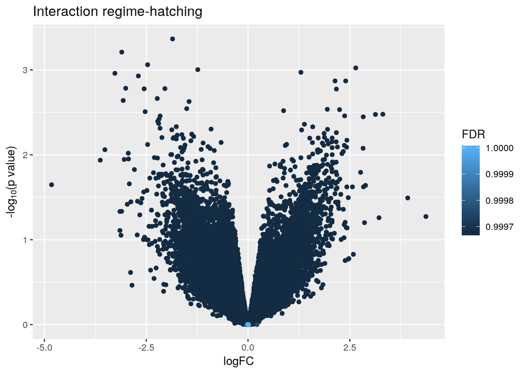

```r
z1 <- topTags(qlf6, n=NumOfTags)$table
z1$logPValue <- -log10(z1$PValue)
ggplot(data=z1, mapping=aes(x=logFC, y=logPValue, color=FDR)) +
   geom_point() + theme_grey() + ylab(expression(paste("-log"[10], plain("(p value)")))) +
   ggtitle('Interaction regime-hatching')
```

According to model 6, there are 0 tags with a significant interaction term between selective regime and hatching condition at FDR = 0.25.

## Model 5

```r
qlf5 <- glmQLFTest(fit5, coef=4)
topTags(qlf5)
```

```
## Coefficient:  regimerandom:diapausediapause
##                    logFC     logCPM        F       PValue       FDR
## TCONS_00027579 -1.240476  4.1322047 26.30317 0.0002602219 0.9999678
## TCONS_00073422  2.445762  0.3573781 24.34939 0.0003588465 0.9999678
## TCONS_00034103 -2.065226  4.0916701 24.28128 0.0003630074 0.9999678
## TCONS_00065474 -2.189305 -0.8320652 21.76299 0.0005653343 0.9999678
## TCONS_00009010  2.659012 -1.5757685 21.30288 0.0006153032 0.9999678
## TCONS_00061427 -3.208731 -1.1544340 20.99548 0.0006515772 0.9999678
## TCONS_00032972  2.543394  1.0476130 17.93183 0.0011919608 0.9999678
## TCONS_00035262 -2.523975 -1.5226597 16.29847 0.0016909075 0.9999678
## TCONS_00073421  1.904264  0.6925947 16.07411 0.0017771151 0.9999678
## TCONS_00051238  2.803414 -0.1322084 15.97409 0.0018172001 0.9999678
```

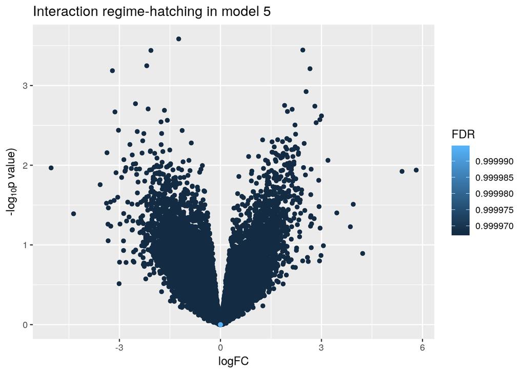

```r
z1 <- topTags(qlf5, n=NumOfTags)$table
z1$logPValue <- -log10(z1$PValue)
ggplot(data=z1, mapping=aes(x=logFC, y=logPValue, color=FDR)) +
   geom_point() + theme_grey() + ylab(expression(paste("-log"[10], plain("p value)")))) +
   ggtitle('Interaction regime-hatching in model 5')
```

According to model 5, there are 0 tags with a significant interaction term between selective regime and hatching condition at FDR = 0.25. And this is how models 5 and 6 agree on what genes have such significant interaction term:

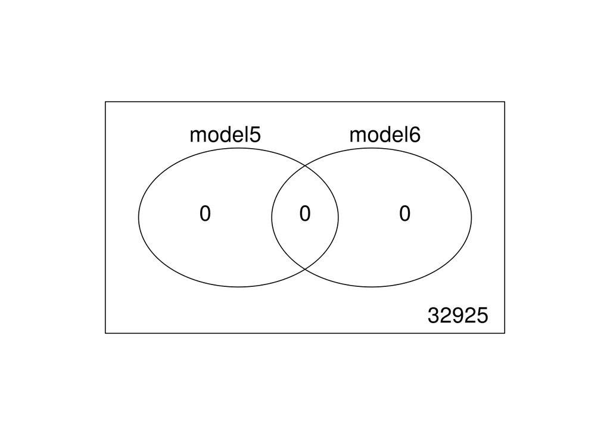

```r
significant <- cbind(model5 = topTags(qlf5, n=NumOfTags, sort.by='none')$table$FDR <= 0.25,
                     model6 = topTags(qlf6, n=NumOfTags, sort.by='none')$table$FDR <= 0.25)
vennDiagram(vennCounts(significant))
```

# Interaction between selective regime and population

When testing for significant coefficients showing the effect of the nested population, there are not one but 4 possible coefficients, each with a different fold change. For the volcano plot, I want to use for each gene the fold change that is most extreme (either positive or negative).

## Model 6

```r
qlf6  <- glmQLFTest(fit6, coef=5:8)
topTags(qlf6)
```

```
## Coefficient:  regimeregular:NestedPop2 regimerandom:NestedPop2 regimeregular:NestedPop3 regimerandom:NestedPop3
##                logFC.regimeregular.NestedPop2
## TCONS_00026548                     -1.1413506
## TCONS_00030123                     -2.6906255
## TCONS_00063463                     -0.2974970
## TCONS_00025027                     -0.8438688
## TCONS_00003241                     -1.1571433
## TCONS_00033569                      2.3233280
## TCONS_00045925                      0.3229189
## TCONS_00030498                     -1.0749831
## TCONS_00013983                      0.2598862
## TCONS_00064052                      0.1377394
##                logFC.regimerandom.NestedPop2
## TCONS_00026548                  -6.032047768
## TCONS_00030123                   3.047168752
## TCONS_00063463                   5.254675866
## TCONS_00025027                  -1.866311560
## TCONS_00003241                  -6.303036583
## TCONS_00033569                   6.038682387
## TCONS_00045925                  -0.008467676
## TCONS_00030498                   2.485216101
## TCONS_00013983                  -0.173188313
## TCONS_00064052                  -4.154779242
##                logFC.regimeregular.NestedPop3
## TCONS_00026548                    -0.27140452
## TCONS_00030123                    -0.87207561
## TCONS_00063463                    -0.01528423
## TCONS_00025027                    -1.57951581
## TCONS_00003241                    -0.12955714
## TCONS_00033569                     1.06772906
## TCONS_00045925                     0.37486312
## TCONS_00030498                    -0.34625570
## TCONS_00013983                    -0.71391219
## TCONS_00064052                     0.09669042
##                logFC.regimerandom.NestedPop3   logCPM         F
## TCONS_00026548                    -2.3310170 3.974369 130.77984
## TCONS_00030123                    -0.1547378 4.215993  99.96267
## TCONS_00063463                     5.5669019 5.712106  75.24105
## TCONS_00025027                     7.9373826 1.856160  72.27695
## TCONS_00003241                    -5.1072724 2.915626  70.27872
## TCONS_00033569                     0.3436243 1.246665  68.95986
## TCONS_00045925                    -3.8559283 4.119313  66.51301
## TCONS_00030498                     2.2910225 4.776605  61.90379
## TCONS_00013983                     1.9734611 5.267264  59.97537
## TCONS_00064052                    -0.2325656 3.659203  52.44031
##                      PValue        FDR
## TCONS_00026548 4.622482e-07 0.01521952
## TCONS_00030123 1.258659e-06 0.02072067
## TCONS_00063463 3.605330e-06 0.02670425
## TCONS_00025027 4.181313e-06 0.02670425
## TCONS_00003241 4.636239e-06 0.02670425
## TCONS_00033569 4.971081e-06 0.02670425
## TCONS_00045925 5.677442e-06 0.02670425
## TCONS_00030498 7.390019e-06 0.03035915
## TCONS_00013983 8.298630e-06 0.03035915
## TCONS_00064052 1.355099e-05 0.04261569
```

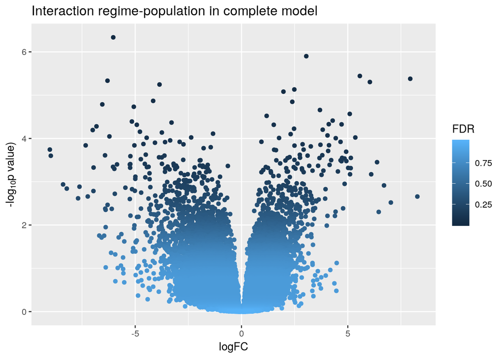

```r
z1 <- topTags(qlf6, n=NumOfTags)$table
z1$logPValue <- -log10(z1$PValue)
z1$logFC <- z1[cbind(1:NumOfTags, apply(abs(z1[,1:4]), 1, which.max))]
ggplot(data=z1, mapping=aes(x=logFC, y=logPValue, color=FDR)) +
   geom_point() + theme_grey() + ylab(expression(paste("-log"[10], plain("p value)")))) +
   ggtitle('Interaction regime-population in complete model')
```

According to model 6, there are 0 tags with a significant interaction term between selective regime and population, at FDR = 0.01.

## Model 4

```r
qlf4 <- glmQLFTest(fit4, coef=4:7)
topTags(qlf4)
```

```
## Coefficient:  regimeregular:NestedPop2 regimerandom:NestedPop2 regimeregular:NestedPop3 regimerandom:NestedPop3
##                logFC.regimeregular.NestedPop2
## TCONS_00026548                     -1.1409526
## TCONS_00030123                     -2.6894792
## TCONS_00063463                     -0.2951510
## TCONS_00033569                      2.3243806
## TCONS_00003241                     -1.1463190
## TCONS_00025027                     -0.8621010
## TCONS_00030498                     -1.0706625
## TCONS_00013983                      0.2617711
## TCONS_00045925                      0.3280177
## TCONS_00064052                      0.1330492
##                logFC.regimerandom.NestedPop2
## TCONS_00026548                   -6.03305847
## TCONS_00030123                    3.04802029
## TCONS_00063463                    5.24098752
## TCONS_00033569                    6.03890907
## TCONS_00003241                   -6.30693601
## TCONS_00025027                   -1.87059247
## TCONS_00030498                    2.48166748
## TCONS_00013983                   -0.17693865
## TCONS_00045925                   -0.02808466
## TCONS_00064052                   -4.14807641
##                logFC.regimeregular.NestedPop3
## TCONS_00026548                    -0.27173460
## TCONS_00030123                    -0.86878630
## TCONS_00063463                    -0.02771677
## TCONS_00033569                     1.06681900
## TCONS_00003241                    -0.13724639
## TCONS_00025027                    -1.54901147
## TCONS_00030498                    -0.34445905
## TCONS_00013983                    -0.72020809
## TCONS_00045925                     0.36919873
## TCONS_00064052                     0.09660807
##                logFC.regimerandom.NestedPop3   logCPM         F
## TCONS_00026548                    -2.3291951 3.974440 149.00980
## TCONS_00030123                    -0.1557691 4.216033 114.68553
## TCONS_00063463                     5.5645213 5.712132  83.08438
## TCONS_00033569                     0.3430100 1.246348  79.28693
## TCONS_00003241                    -5.1033503 2.915882  78.22682
## TCONS_00025027                     7.9009948 1.855765  76.60235
## TCONS_00030498                     2.2887331 4.776628  65.90891
## TCONS_00013983                     1.9712843 5.267254  62.26239
## TCONS_00045925                    -3.8599191 4.119315  59.21081
## TCONS_00064052                    -0.2271281 3.659217  59.02239
##                      PValue         FDR
## TCONS_00026548 4.275333e-08 0.001407653
## TCONS_00030123 1.325843e-07 0.002182670
## TCONS_00063463 5.291482e-07 0.004107298
## TCONS_00033569 6.461973e-07 0.004107298
## TCONS_00003241 6.844032e-07 0.004107298
## TCONS_00025027 7.484825e-07 0.004107298
## TCONS_00030498 1.418573e-06 0.006672358
## TCONS_00013983 1.805327e-06 0.007430050
## TCONS_00045925 2.232558e-06 0.007450279
## TCONS_00064052 2.262803e-06 0.007450279
```

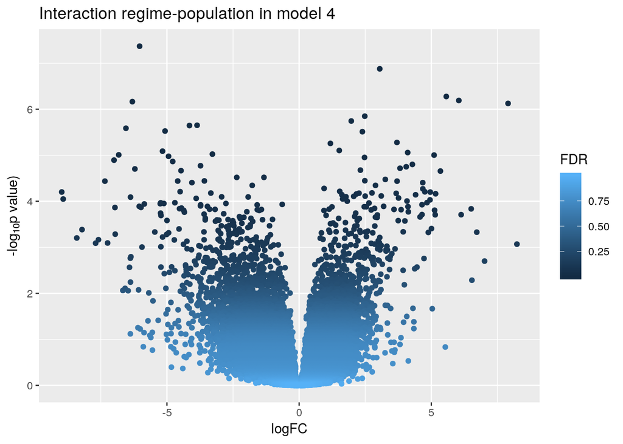

```r
z1 <- topTags(qlf4, n=NumOfTags)$table
z1$logPValue <- -log10(z1$PValue)
z1$logFC <- z1[cbind(1:NumOfTags, apply(abs(z1[,1:4]), 1, which.max))]
ggplot(data=z1, mapping=aes(x=logFC, y=logPValue, color=FDR)) +
   geom_point() + theme_grey() + ylab(expression(paste("-log"[10], plain("p value)")))) +
   ggtitle('Interaction regime-population in model 4')
```

According to model 4, there are 13 tags with a significant interaction term between selective regimew and population, at FDR = 0.01. And this is how the genes identified as having such significant coefficients match between results of models 4 and 6:

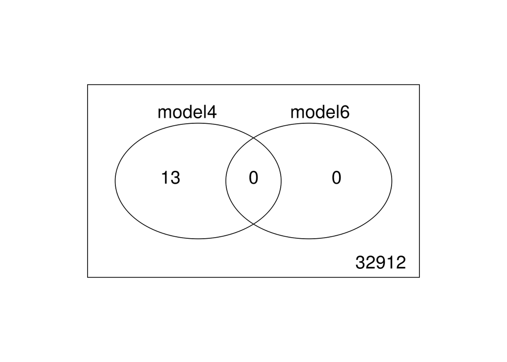

```r
significant <- cbind(model4 = topTags(qlf4, n=NumOfTags, sort.by='none')$table$FDR <= 0.01,
                     model6 = topTags(qlf6, n=NumOfTags, sort.by='none')$table$FDR <= 0.01)
vennDiagram(vennCounts(significant))
```